# 210_Exam_1

Davis George

September 13, 2016

# Setup

```r
#Load Packages
library(dplyr)
```

```r
library(ggplot2)
library(mosaic)
library(Sleuth3)
library(tigerstats)
#Load the required data from csv, and make sure it is what we want to look at.
lead <- read.csv("lead-ds.csv")
head(lead)
```

```
##    Id Area  Age Sex Iqv_inf Iqv_comp Iqv_ar Iqv_ds Iqv_raw Iqp_pc Iqp_bd
## 1 101    3 1101   1       3        4      3      5      15     10      8
## 2 102    3  905   1       7        9      7      6      29      8      7
## 3 103    3 1101   1       4        9      5      3      21     10      7
## 4 104    2  611   1       4        6      6      6      22      5      8
## 5 105    1 1103   1       5        4      8      5      22      5     10
## 6 106    2  606   1       5       12     11      9      37     14      7
##   Iqp_oa Iqp_cod Iqp_raw HH_index Iqv Iqp Iqf Iq_type Lead_type Ld72 Ld73
## 1      8       5      31       77  61  85  70       1         1   25   18
## 2     10       9      34       77  82  90  85       1         1   31   28
## 3      7      20      44       30  70 107  86       1         1   30   29
## 4      5      13      31       77  72  85  76       1         1   29   30
## 5     13      12      40       62  72 100  84       1         1    2   34
## 6      7      10      38       72  95  97  96       1         1   29   25
##   Fst2yrs Totyrs Pica Colic Clumsi Irrit Convul X2Plat_r X2Plat_l Visrea_r
## 1       2     11    2     2      2     2      2       16       16       36
## 2       2      6    2     2      2     2      2       17       16       23
## 3       2      5    2     2      2     2      2       16       17       20
## 4       2      5    2     2      2     1      2       11        9       34
## 5       1     11    2     2      2     1      2       17       16       26
## 6       2      6    2     2      2     2      2       16       14       29
##   Visrea_l Audrea_r Audrea_l FWT_r FWT_l Hyperact group Age.years
## 1       38       27       25    72    52       NA     1 11.083333
## 2       19       18       28    61    48        0     1  9.416667
## 3       24       16       17    46    49       NA     1 11.083333
## 4       42       35       30    48    41        2     1  6.916667
## 5       34       31       33    51    42       NA     1 11.250000
## 6       26       28       27    49    35        0     1  6.500000
```

```r
#Let's transform our "ld72" and "ld73" variables into one continuous variable called "lead_final" by averaging.

#ld72 doesn't include participation from all kids, so ld73 should be the better bet.
lead$lead_final <- ((lead$Ld72 + lead$Ld73)/2)

#Let's transform our "Sex" variable to 0's and 1's so a proportion can be established.
lead$sex_proportion <- 1 * (lead$Sex == 1)

#Subset groups
lead_sub_control <- subset(lead, group == 1)
lead_sub_treat <- subset(lead, group == 2)

head(lead)
```

```
##    Id Area  Age Sex Iqv_inf Iqv_comp Iqv_ar Iqv_ds Iqv_raw Iqp_pc Iqp_bd
## 1 101    3 1101   1       3        4      3      5      15     10      8
## 2 102    3  905   1       7        9      7      6      29      8      7
## 3 103    3 1101   1       4        9      5      3      21     10      7
## 4 104    2  611   1       4        6      6      6      22      5      8
## 5 105    1 1103   1       5        4      8      5      22      5     10
## 6 106    2  606   1       5       12     11      9      37     14      7
##   Iqp_oa Iqp_cod Iqp_raw HH_index Iqv Iqp Iqf Iq_type Lead_type Ld72 Ld73
## 1      8       5      31       77  61  85  70       1         1   25   18
## 2     10       9      34       77  82  90  85       1         1   31   28
## 3      7      20      44       30  70 107  86       1         1   30   29
## 4      5      13      31       77  72  85  76       1         1   29   30
## 5     13      12      40       62  72 100  84       1         1    2   34
## 6      7      10      38       72  95  97  96       1         1   29   25
##   Fst2yrs Totyrs Pica Colic Clumsi Irrit Convul X2Plat_r X2Plat_l Visrea_r
```

[output cut: 20 more lines]

# Test

## (1/1a) - In the paper, the authors state, “Mean age in the lead-absorption group was 8.3 (SD=3.4) and in the control group was 9.3 (SD=3.6). This difference was not statistically significant (p>.10). Because the authors found a p-value>.10, the difference in average age between the groups occurred by chance. (True/False)

False.

## (2/1b)- In the paper, the authors state, “Mean age in the lead-absorption group was 8.3 (SD=3.4) and in the control group was 9.3 (SD=3.6). This difference was not statistically significant (p>.10). Because the authors found a p-value>.10, there is no reason to be concerned about the 1 year difference in average age between the groups. (True/False)

False.

## (3/1c) - Test the null hypothesis that the average age is equal in the two groups against the alternative that the control group is older. (You may assume equal variances in the two groups.) i) Test statistic: ii) P-value: iii) Conclusion: Reject null hypothesis Fail to reject null hypothesis iv) R code and output

To perform a t-test, the program in R calculates a t-statistic, or a measure of how far away our observed values (or differences) are on a t-distribution. The program in R then calculates a cumalative density (under the curve of the t-distribution) for our observed t-statistic, which represents the probability that an observation more extreme or as extreme as our observed values will occur, assuming the null is true. This probability is the p-value used for various statistical tests.

$$t = \frac{(u_1-u_2)}{SE_{pooled}}$$

To calculate a t-statistic (for two groups, assuming equal variance), the program takes the difference between the means of the two groups
$$u_1 and u_2$$
, and divides by the pooled Standard Error.

$${SE_{pooled} = \sqrt{(SE_1)^2 + (SE_2)^2}}$$

The pooled Standard error is calculated by taking the square root of the Standard Error of the first distribution, and the Standard Error of the second distribution.

$$SE_1 = \frac{(σ)}{\sqrt{n_2}}$$

$$SE_2 = \frac{(σ)}{\sqrt{n_2}}$$

These standard errors are calculated by taking the standard deviation of the response variable for each group, and dividing it by the square root of the number of observations in each group. This helps to adjust for differences in the size of each group (assuming that larger groups have less variablity).

```r
t_done <- t.test(lead$Age.years ~ lead$group, alternative = "greater", mu = 0, var.equal = TRUE)
t_done
```

```
##
##  Two Sample t-test
##
## data:  lead$Age.years by lead$group
## t = 1.6197, df = 122, p-value = 0.05394
## alternative hypothesis: true difference in means is greater than 0
## 95 percent confidence interval:
##  -0.02468564         Inf
## sample estimates:
## mean in group 1 mean in group 2
##        9.327991        8.269928
```

## (4/1d) - The authors found p>.10. This is larger than the p-value you got or should have gotten in 1b. Circle the number(s) of the possible reason(s) the authors could have gotten a larger p-value? (12.0 Points)

1. The authors used a standard error that was too large - As the standard error increases (as shown in the aforementioned formula), the t-value decreases, in turn increasing the p-value.
2. - The control group has a higher mean, so doing a t-test in the opposite direction yields a high probability that the null hypothesis is true.
3. two-tailed tests have higher p-values by definition.

## (5/2a) - In the paper, the authors present the following gender (male/female) distribution between groups. Lead-absorption group Control group N=46 N=78 M/F 30/16 (65% / 35%) 45/33 (50% / 42%) State the error presented and correct it. (5.0 Points)

$In the actual data, there are 46 boys in the control group, and 32 girls. This leads to proportions of 59% male, and 41% male, instead of 45/33 (50%/42%).$

## (6/2b) - Conduct a t-test for the difference in percentage of boys between the lead group and the control group. Test statistic: Degrees of Freedom: p-value: Conclusion: R code: (10.0 Points)

To perform a t-test, the program in R calculates a t-statistic, or a measure of how far away our observed values (or differences) are on a t-distribution. The program in R then calculates a cumalative density (under the curve of the t-distribution) for our observed t-statistic, which represents the probability that an observation more extreme or as extreme as our observed values will occur, assuming the null is true. This probability is the p-value used for various statistical tests.

$$t = \frac{(u_1-u_2)}{SE_{pooled}}$$

To calculate a t-statistic (for two groups, assuming equal variance), the program takes the difference between the means of the two groups
$$u_1 and u_2$$
, and divides by the pooled Standard Error.

$${SE_{pooled} = \sqrt{(SE_1)^2 + (SE_2)^2}}$$

The pooled Standard error is calculated by taking the square root of the Standard Error of the first distribution, and the Standard Error of the second distribution.

$$SE_1 = \frac{(σ)}{\sqrt{n_2}}$$

$$SE_2 = \frac{(σ)}{\sqrt{n_2}}$$

*TA’s instructed us that we should treat the variances in the two groups as equal here, and follow the standard formula for a two-sample t-test (two proportion Z-test)*

See proportion transformation in “Setup” of this document.

```r
t_done_male_rep <- t.test(lead$sex_proportion ~ lead$group, alternative = "greater", mu = 0, var.equal = TRUE)
t_done_male_rep
```

```
##
##  Two Sample t-test
##
## data:  lead$sex_proportion by lead$group
## t = -0.68519, df = 122, p-value = 0.7527
## alternative hypothesis: true difference in means is greater than 0
## 95 percent confidence interval:
##  -0.213447       Inf
## sample estimates:
## mean in group 1 mean in group 2
##       0.5897436       0.6521739
```

```r
summary(t_done_male_rep)
```

```
##             Length Class  Mode
## statistic   1      -none- numeric
## parameter   1      -none- numeric
## p.value     1      -none- numeric
## conf.int    2      -none- numeric
## estimate    2      -none- numeric
## null.value  1      -none- numeric
## alternative 1      -none- character
## method      1      -none- character
## data.name   1      -none- character
```

## (7/2c) - Conduct a test for independence between gender and group? Test statistic: Degrees of freedom: P-value: Conclusion: Reject null hypothesis Fail to reject null hypothesis R code and output (10.0 Points)

In a test for independence, we are looking to see whether the relative ratios of one variable (for instance, proportion of males/females) changes based on another variable (for instance, group). An overview of this can be visualized with a contingency table.

*Note here that for this contingency table, the rows indicate males and females (1 = males, 2 = females), while the columns indicate group (1 = control, 2 = lead-absorption)*

A formula for a statistical test of independence for contingency tables is expressed as:

$X^2 = \sum{\frac{(O_i-E_i)^2}{E_i}}$

With O_i and E_i representing the observed values and the expected values (which are expected given that the null hypothesis that there is no difference between groups is true)

```r
tbl = table(lead$Sex, lead$group)
tbl #contingency table
```

```
##
##      1  2
##   1 46 30
##   2 32 16
```

```r
indep_test <- chisq.test(tbl)
indep_test
```

```
##
##  Pearson's Chi-squared test with Yates' continuity correction
##
## data:  tbl
## X-squared = 0.24862, df = 1, p-value = 0.618
```

## (8/2d) - Because p>.05, the overrepresentation of males in the lead-absorption group cannot be a confounding factor for the differences observed between the lead-absorption and control groups. (True/False) (3.0 Points)

False.

## (9/2e) - Conduct a test for the difference in proportion of males between the lead and control group against a two-tail alternative. Test statistic: Degrees of freedom: P-value: Conclusion: Reject null hypothesis Fail to reject null hypothesis R code and output (10.0 Points)

To perform a t-test, the program in R calculates a t-statistic, or a measure of how far away our observed values (or differences) are on a t-distribution. The program in R then calculates a cumalative density (under the curve of the t-distribution) for our observed t-statistic, which represents the probability that an observation more extreme or as extreme as our observed values will occur, assuming the null is true. This probability is the p-value used for various statistical tests.

$$t = \frac{(u_1-u_2)}{SE_{pooled}}$$

To calculate a t-statistic (for two groups, assuming equal variance), the program takes the difference between the means of the two groups
$$u_1 and u_2$$
, and divides by the pooled Standard Error.

$${SE_{pooled} = \sqrt{(SE_1)^2 + (SE_2)^2}}$$

The pooled Standard error is calculated by taking the square root of the Standard Error of the first distribution, and the Standard Error of the second distribution.

$$SE_1 = \frac{(σ)}{\sqrt{n_2}}$$

$$SE_2 = \frac{(σ)}{\sqrt{n_2}}$$

*TA’s instructed us that we should treat the variances in the two groups as equal here, and follow the standard formula for a two-sample t-test (two proportion Z-test)*

See proportion transformation in “Setup” of this document.

```r
t_done_male_rep <- t.test(lead$sex_proportion ~ lead$group, alternative = "two.sided", mu = 0, var.equal = TRUE)
t_done_male_rep
```

```
##
##  Two Sample t-test
##
## data:  lead$sex_proportion by lead$group
## t = -0.68519, df = 122, p-value = 0.4945
## alternative hypothesis: true difference in means is not equal to 0
## 95 percent confidence interval:
##  -0.2428005  0.1179398
## sample estimates:
## mean in group 1 mean in group 2
##       0.5897436       0.6521739
```

```r
summary(t_done_male_rep)
```

```
##             Length Class  Mode
## statistic   1      -none- numeric
## parameter   1      -none- numeric
## p.value     1      -none- numeric
## conf.int    2      -none- numeric
## estimate    2      -none- numeric
## null.value  1      -none- numeric
## alternative 1      -none- character
## method      1      -none- character
## data.name   1      -none- character
```

## (10/3) - The authors give the counts and rates (%) of 5 medical symptoms in the lead-absorption and control groups. Lead-absorption Control Pica 7 (15%) 4 ( 5%) Abdominal Colic 12 (26%) 11 (14%) Clumsiness 5 (11%) 6 ( 8%) Irritability 18 (39%) 21 (27%) Convulsions 3 ( 7%) 3 ( 4%) Tests of the differences in rates of symptoms between groups were not statistically significant for any of the 5 medical symptoms. If in reality, the rates of each symptom were equal in the lead-absorption and control groups, what is the probability that, by chance, 5 of 5 of the symptoms would show higher rates in the lead-absorption group. You may assume the presence/absence of each symptom is independent of the presence/absence of other symptoms. (10.0 Points)

If the rates of symptoms were equal in the lead absorption and control groups, then the probability that by, chance, 5 out of 5 symptoms would show higher rates is represented by the probability that a random sampling of rates of medical symptoms would land > 0 SD away from the mean on 5 consecutive normal distributions, assuming that each symptoms presence is independent of the other symptoms. The probability of one such occurence is the area under a normal curve represented by any values > 0 SD away from the mean.

This probability is represented here for any symptom “x”:

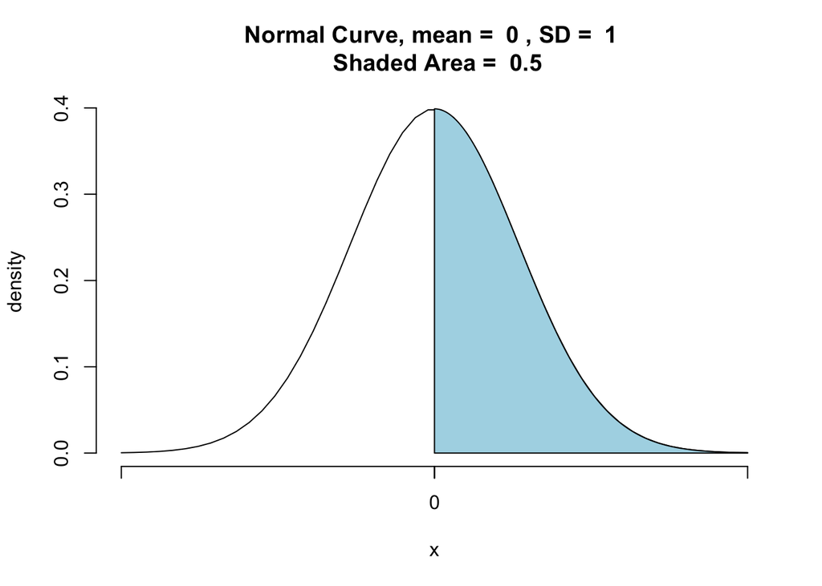

```
## [1] 0.5
```

```r
pnormGC(0, region="above", mean=0,sd=1,graph=TRUE)
```

Therefore, the probability of all five symptoms showing higher rates is equal to the probability of each symptom showing higher rates, which assuming that they are independent, is equal to:

$p(5 symptoms) = 0.03125$.

*TA’s assisted me in the wording of this problem*

## (11/4a) - In the scatterplot figure, there are 2 regressions, one for the lead-absorption group and one for the control group. The outcome variable (Y), finger/wrist tapping is a neurological test that counts the number of taps the child can make in 10 seconds with a stylus on a metal plate while their hand and wrist are held above the table. The predictor variable (X) is age in years. The regressions equations are presented below. Lead-absorption group N=35, Mean(Y)= 46.5, SD(Y)=13.2 Y = 22 + 2.5(X) R^2=.30 standard error intercept = 7, standard error slope =.7 Control group N=64, Mean(Y)= 54.1, SD(Y)=12.3 Y = 26 + 2.7(X) R^2=.45 standard error intercept = 4, standard error slope =.4 The rms-error for both groups is closest to (5, 10, 20, 25, 30 ) (5.0 Points)

Let’s first create the two linear models.

```r
#Control Group
lm_control <- lm(FWT_r ~ Age.years, data = lead_sub_control)
lm_control
```

```
##
## Call:
## lm(formula = FWT_r ~ Age.years, data = lead_sub_control)
##
## Coefficients:
## (Intercept)    Age.years
##      26.264        2.689
```

```r
summary(lm_control)
```

```
##
## Call:
## lm(formula = FWT_r ~ Age.years, data = lead_sub_control)
##
## Residuals:
##     Min      1Q  Median      3Q     Max
## -34.984  -4.207   0.975   6.116  16.881
##
## Coefficients:
##             Estimate Std. Error t value Pr(>|t|)
## (Intercept)  26.2641     4.0482   6.488 1.64e-08 ***
## Age.years     2.6891     0.3748   7.175 1.07e-09 ***
## ---
## Signif. codes:  0 '***' 0.001 '**' 0.01 '*' 0.05 '.' 0.1 ' ' 1
##
## Residual standard error: 9.148 on 62 degrees of freedom
##   (14 observations deleted due to missingness)
## Multiple R-squared:  0.4536, Adjusted R-squared:  0.4448
## F-statistic: 51.47 on 1 and 62 DF,  p-value: 1.072e-09
```

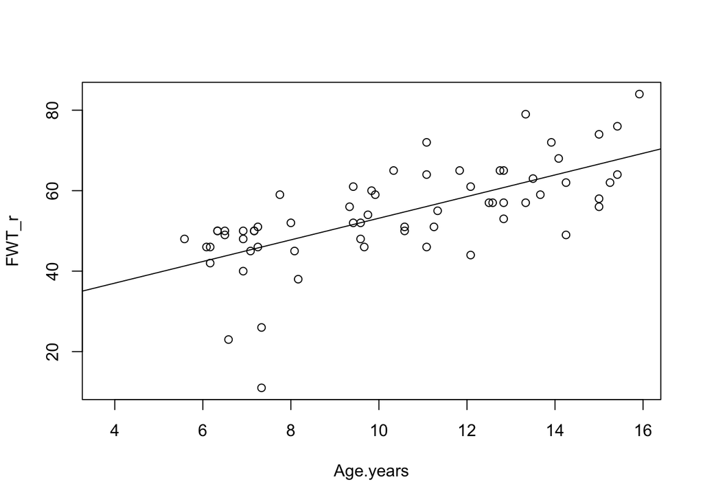

```r
plot(FWT_r ~ Age.years, data = lead_sub_control)
abline(lm_control)
```

```r
#Treatment Group
lm_treat <- lm(FWT_r ~ Age.years, data = lead_sub_treat)
lm_treat
```

```
##
## Call:
## lm(formula = FWT_r ~ Age.years, data = lead_sub_treat)
##
## Coefficients:
## (Intercept)    Age.years
##      22.415        2.524
```

```r
summary(lm_treat)
```

```
##
## Call:
## lm(formula = FWT_r ~ Age.years, data = lead_sub_treat)
##
## Residuals:
##     Min      1Q  Median      3Q     Max
## -31.080  -4.727  -0.597   6.266  37.027
##
## Coefficients:
##             Estimate Std. Error t value Pr(>|t|)
## (Intercept)  22.4149     6.6511    3.37 0.001927 **
## Age.years     2.5241     0.6678    3.78 0.000625 ***
## ---
## Signif. codes:  0 '***' 0.001 '**' 0.01 '*' 0.05 '.' 0.1 ' ' 1
##
## Residual standard error: 11.21 on 33 degrees of freedom
##   (11 observations deleted due to missingness)
## Multiple R-squared:  0.3022, Adjusted R-squared:  0.281
## F-statistic: 14.29 on 1 and 33 DF,  p-value: 0.0006253
```

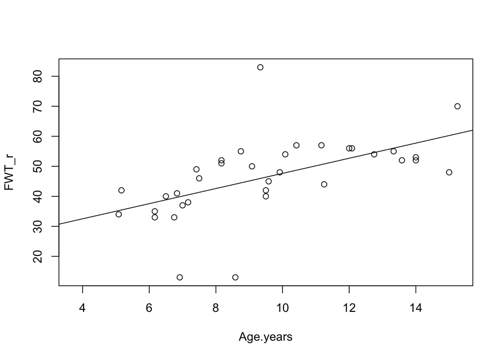

```r
plot(FWT_r ~ Age.years, data = lead_sub_treat)
abline(lm_treat)
```

We can create a function that calculates root-mean-squared error by squaring the residuals (error-terms), taking the mean, and then the square-root.

```r
rmse <- function(error)
{
    sqrt(mean(error^2))
}
error_term_t <- lm_treat$residuals
error_term_c <- lm_control$residuals
coeff_t <- lm_treat$coefficients
coeff_c <- lm_control$coefficients
```

So, the RMS-error for the treatment group is $10.8852425$ and $9.0043249$ for the control group.

Both RMS-errors are closest to $10$

## (12/4b) - The rms-error is larger for which group? (3.0 Points)

The RMS-error is larger in the treatment group, at $10.8852425$ versus $9.0043249$.

## (13/4c) - At an age of 9 years the predicted value of finger/right for the lead-absorption group is (3.0 Points)

First, we’ll make a small data-frame with our age value of 9 years to input into the predict function.

```r
Age.years <- c(9)
df_test = data.frame(Age.years)
```

At an age of 9 years, the predicted value of finger/right for the lead-absorption group is:

$45.1320262$ taps.

## (14/4c) - At an age of 9 years the predicted value of finger/right for the lead-absorption group is (3.0 Points)

First, we’ll make a small data-frame with our age value of 9 years to input into the predict function.

```r
Age.years <- c(9)
df_test = data.frame(Age.years)
```

At an age of 9 years, the predicted value of finger/right for the lead-absorption group is:

$45.1320262$ taps.

## (15/4d) - At an age of 9 years the predicted value of finger/right for the control group is (3.0 Points)

We’ll re-use the data-frame “df_test” from earlier but instead use our linear model representing the control group, to obtain:

$50.4660081$ taps.

## (16/4e-i) The difference in slopes between the lead absorption and control group is statistically significant. (True/False) (5.0 Points)

Let’s run a t-test for the difference between the two slopes:

```r
SE_slope_t = 0.7
SE_slope_c = 0.4
SE_slope_pool <- sqrt((SE_slope_t)^2 + (SE_slope_c)^2)
df = ((35 + 64) - 4)

t_stat <- (coeff_c[2] - coeff_t[2]) / SE_slope_pool
onepval = 1 - pt(t_stat, df)
t_stat
```

```
## Age.years
## 0.2046207
```

```r
onepval
```

```
## Age.years
## 0.4191531
```

$False.$

*TA’s gave guidance on this problem regarding proper degrees of freedom to use*

## (17/4e-ii) - The difference in intercepts between the lead absorption and control group is statistically significant. (True/False) (5.0 Points)

Let’s run a t-test for the difference between the two intercepts:

```r
SE_inter_t = 7
SE_inter_c = 4
SE_inter_pool <- sqrt((SE_inter_t)^2 + (SE_inter_c)^2)
df = ((35 + 64) - 4)

t_stat <- (coeff_c[1] - coeff_t[1]) / SE_inter_pool
onepval = 1 - pt(t_stat, df)
t_stat
```

```
## (Intercept)
##   0.4774404
```

```r
onepval
```

```
## (Intercept)
##   0.3170726
```

$False.$

*TA’s gave guidance on this problem regarding proper degrees of freedom to use*

## (19/4e-iv) - These regressions provide evidence that the statistically significant difference in average finger/right between the lead-absorption and control groups (46.5 vs 54.1, t = -2.8, p = .007) could be partially due to age. (True/False) (3.0 Points)

$True$

## (20/4e-v) - The near parallel slopes tell us that the average of finger/right is the same for the lead-absorption and control groups at each age level. (True/False) (3.0 Points)

$False$

## (21/4e-vi) - Suppose lead absorption has no impact on motor skills. Because the regression line goes through the point of averages, and the control group is one year older than the lead-absorption group, the regression line for the control group would be about 2.5 points higher than the regression line for the lead-absorption group. (True/False) (3.0 Points)

$True$

## (22/4f) - R code and output to replicate these two regression lines. (10.0 Points)

```r
#Code from above reproduced here
#Control Group
lm_control <- lm(FWT_r ~ Age.years, data = lead_sub_control)
lm_control
```

```
##
## Call:
## lm(formula = FWT_r ~ Age.years, data = lead_sub_control)
##
## Coefficients:
## (Intercept)    Age.years
##      26.264        2.689
```

```r
summary(lm_control)
```

```
##
## Call:
## lm(formula = FWT_r ~ Age.years, data = lead_sub_control)
##
## Residuals:
##     Min      1Q  Median      3Q     Max
## -34.984  -4.207   0.975   6.116  16.881
##
## Coefficients:
##             Estimate Std. Error t value Pr(>|t|)
## (Intercept)  26.2641     4.0482   6.488 1.64e-08 ***
## Age.years     2.6891     0.3748   7.175 1.07e-09 ***
## ---
## Signif. codes:  0 '***' 0.001 '**' 0.01 '*' 0.05 '.' 0.1 ' ' 1
##
## Residual standard error: 9.148 on 62 degrees of freedom
##   (14 observations deleted due to missingness)
## Multiple R-squared:  0.4536, Adjusted R-squared:  0.4448
## F-statistic: 51.47 on 1 and 62 DF,  p-value: 1.072e-09
```

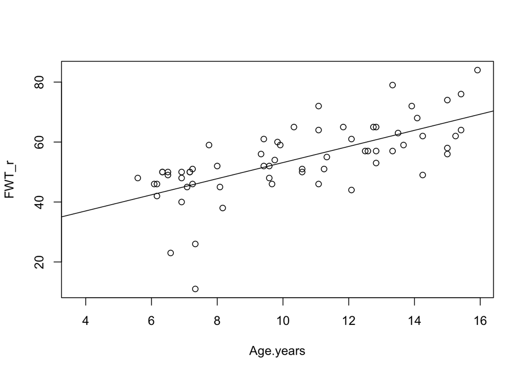

```r
plot(FWT_r ~ Age.years, data = lead_sub_control)
abline(lm_control)
```

```r
#Treatment Group
lm_treat <- lm(FWT_r ~ Age.years, data = lead_sub_treat)
lm_treat
```

```
##
## Call:
## lm(formula = FWT_r ~ Age.years, data = lead_sub_treat)
##
## Coefficients:
## (Intercept)    Age.years
##      22.415        2.524
```

```r
summary(lm_treat)
```

```
##
## Call:
## lm(formula = FWT_r ~ Age.years, data = lead_sub_treat)
##
## Residuals:
##     Min      1Q  Median      3Q     Max
## -31.080  -4.727  -0.597   6.266  37.027
##
## Coefficients:
##             Estimate Std. Error t value Pr(>|t|)
## (Intercept)  22.4149     6.6511    3.37 0.001927 **
## Age.years     2.5241     0.6678    3.78 0.000625 ***
## ---
## Signif. codes:  0 '***' 0.001 '**' 0.01 '*' 0.05 '.' 0.1 ' ' 1
##
## Residual standard error: 11.21 on 33 degrees of freedom
##   (11 observations deleted due to missingness)
## Multiple R-squared:  0.3022, Adjusted R-squared:  0.281
## F-statistic: 14.29 on 1 and 33 DF,  p-value: 0.0006253
```

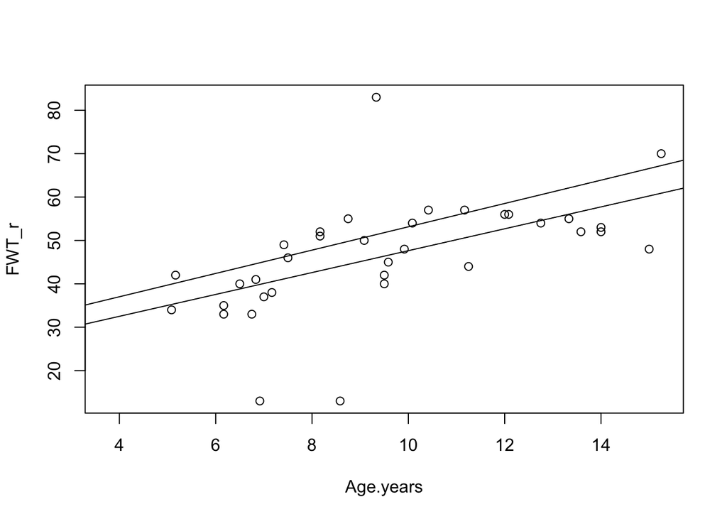

```r
plot(FWT_r ~ Age.years, data = lead_sub_treat)
abline(lm_treat)
abline(lm_control)
```

## (23/8) - Reanalyze the Landrigan data using techniques from The Statistical Sleuth, prior to Chapter 9. Do NOT use multiple regression. Instead of using a dichotomy for the lead variable, use a continuous lead variable. You may choose how you want to use the information in ld72 and ld73 to create this continuous variable. There are many possibilities (using only one of the two lead variables, averaging, maxing, …). Prepare a short paper (2 pages max) with your findings. Students will be randomly chosen from the class to present. Students must use R. Professor Stangl must be able to reproduce the analyses in your presentation. Scoring will include points for correctness, completeness, and clarity. Use lead variable vs. finger/right (FWT_r) and lead variable vs. performance iq (Iqp) (50.0 Points)

## Abstract and Intention

We hope to re-analyze the Landrigan data and utilize a continuous variable to examine the effects of low-level lead absorption on children on IQ and motor skills. This analysis is useful because it will give us information about whether the effects found in the Landrigan data are still found to be significant when lead-absorption is measured as a continuous variable.

## Methodology and Analysis

Because the most significant effects in the Landrigan data corresponded to performance IQ and to right-hand finger tapping (within a given time), these measures will be used as proxies for effects on IQ and motor skills.

Linear models for the effect of the continuous lead variable on our response variables are useful because they help us to understand how well performance in the response variable can be predicted from our explanatory variable.

We’ll first make a linear model for the effect of the continuous lead variable vs. right-hand finger tapping, and examine it’s intercept, coefficient, R-Squared, and a visualization (plot) of the data and the corresponding regression line.

```
##
## Call:
## lm(formula = FWT_r ~ Ld73, data = lead)
##
## Coefficients:
## (Intercept)         Ld73
##     64.6430      -0.4191
```

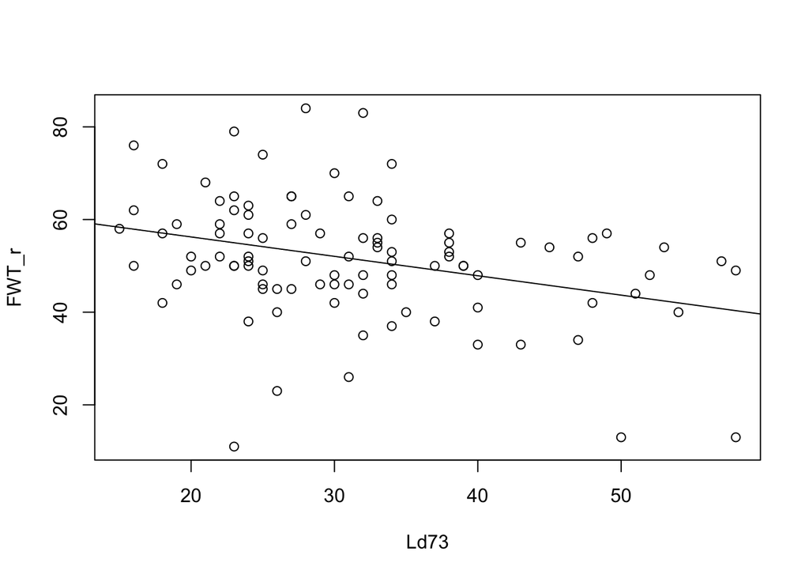

We’ll next make a linear model for the continuous lead variable vs. performance IQ, and examine it’s intercept, coefficient, R-Squared, and a visualization (plot) of the data and the corresponding regression line.

```
##
## Call:
## lm(formula = Iqp ~ Ld73, data = lead)
##
## Coefficients:
## (Intercept)         Ld73
##    106.6012      -0.2138
```

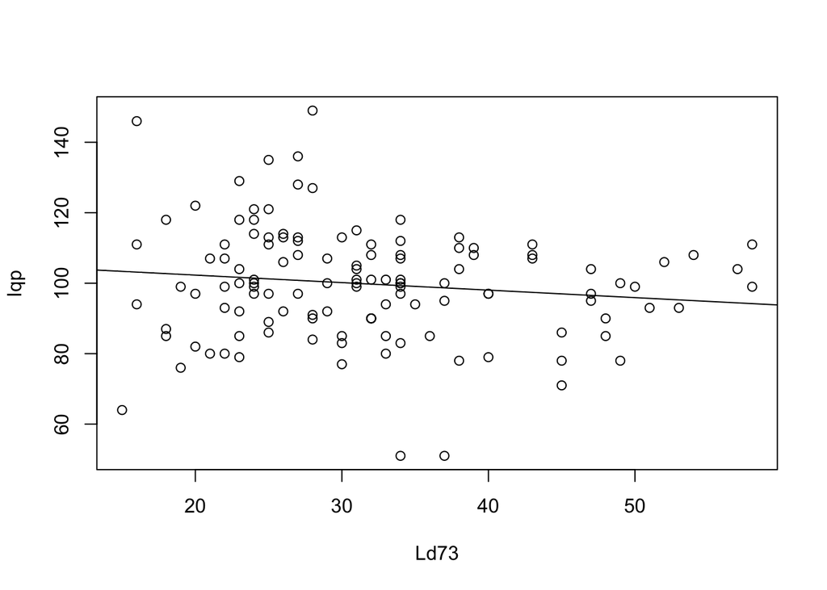

Both linear models seem to indicate that as low-level lead absorption increases, the average of Performance IQ and Finger-Tapping declines. However, we’d like to know whether these decreasing performance effects are likely due to chance, especially because the R-Squared, or proportion of the total variation explained by a linear regression model, is low ($0.1013$ for finger-tapping, and $0.009569$ for performance IQ)

We may need further investigation to see whether the linear regression models indicate that lead-absorption negatively affects performance IQ and motor skills, so we want to see whether the slope of the linear regression models are significantly different from 0, using a t-test. If we reject the null-hypothesis that the slopes of the linear models are 0, then we also have strong evidence that there is some association between low-level lead absorption, and a (negative) association on test performance.

t:

$$t = \frac{slope - 0}{SE}$$

The standard-error is equal to:

$$SE = \hat{\sigma} * \sqrt{\frac{1}{(n-1) * variance_{x}}}$$

where $\hat{\sigma}$ is equal to:

$$\sqrt{\sum{\frac{residuals^2}{df}}}$$

For performance IQ, we get a t-statistic of $-1.4792984$, a p-value of $0.070819$, with degrees of freedom $122$.

## Discussion of results and conclusion

# Extra Credit

## (EC/6) - Confidence interval

```r
var.test(lead$Iqp, lead$group)
```

```
##
##  F test to compare two variances
##
## data:  lead$Iqp and lead$group
## F = 1087.3, num df = 123, denom df = 123, p-value < 2.2e-16
## alternative hypothesis: true ratio of variances is not equal to 1
## 95 percent confidence interval:
##   762.3294 1550.8549
## sample estimates:
## ratio of variances
##           1087.319
```

```r
conf_int <- t.test(lead$Iqp ~ lead$group, var.equal = FALSE, conf.int = TRUE, conf.level = 0.95)$conf.int
conf_int
```

```
## [1]  2.349047 13.191645
## attr(,"conf.level")
## [1] 0.95
```